# R - Animation

Derek Van Berkel

3/26/2020

## Spatial Temporal analysis in R

R’s versatility and extensive ecosystem of packages make it a powerful tool for studying the dynamic interplay of space and time in data.

### Data to download

Download the project folder from canvas for this lab. We will be using the packages `ggplot()` and `gganimate()` to explore spatial dimensions `gganimate` is an extension of the grammar of graphics, as implemented by the ggplot2 package, that adds support for declaring animations using an API familiar to users of ggplot2.

```r
library(readr)
library(ggplot2)
library(ggthemes)
library(gganimate)
library(foreign)
library(dplyr)
library(rnaturalearth)
library(rnaturalearthdata)
library(gifski)
library(lubridate)
#library(tidyverse)
library(wesanderson)
```

1. Let’s open the data

```r
MichFlickr <- read.csv("MichiganFlickr.csv")
```

2. First let’s look at distribution of the data. To plot time series data, we need to change the formate so R understand that it should be read a date. We do this by coersing it using `ad.Date` or `as.POSIXct` function. This is part of the package `Lubridate`, which is helpful for time series data. It can also be used to grab/parse specific parts of a date (e.g year, month etc.)

```r
MichFlickr$date <- as.POSIXct(MichFlickr$dateupload, origin="1970-01-01")
MichFlickr$date <- as.Date(format(MichFlickr$date, format="%Y-%m-%d"))
###We will also give it a value. We want to count the number of photos
MichFlickr$year <- year(MichFlickr$date)
MichFlickr$month <- month(MichFlickr$date, label = TRUE)
MichFlickr$day <- day(MichFlickr$date)
MichFlickr$count<- 1
MichFlickr$Nature<- MichFlickr$predict_Na > 0.6
```

3. To plot time series, we need to summarise the photos per day. We will use the mutate, group_by and summarise function to create this new table

```r
daily_photography <- MichFlickr %>%
  mutate(day = as.Date(date, format="%Y-%m-%d")) %>%
  group_by(day) %>% # group by the day column
  summarise(total_photos=sum(count)) %>%  # calculate the SUM of all precipitation that occurred on each day
  na.omit()
head(daily_photography)
```

```
## # A tibble: 6 × 2
##   day        total_photos
##   <date>            <dbl>
## 1 1975-06-01            1
## 2 1979-04-30            1
## 3 1979-08-25            1
## 4 2000-04-23            1
## 5 2000-06-26            2
## 6 2000-09-21            8
```

4. Now we can plot this data

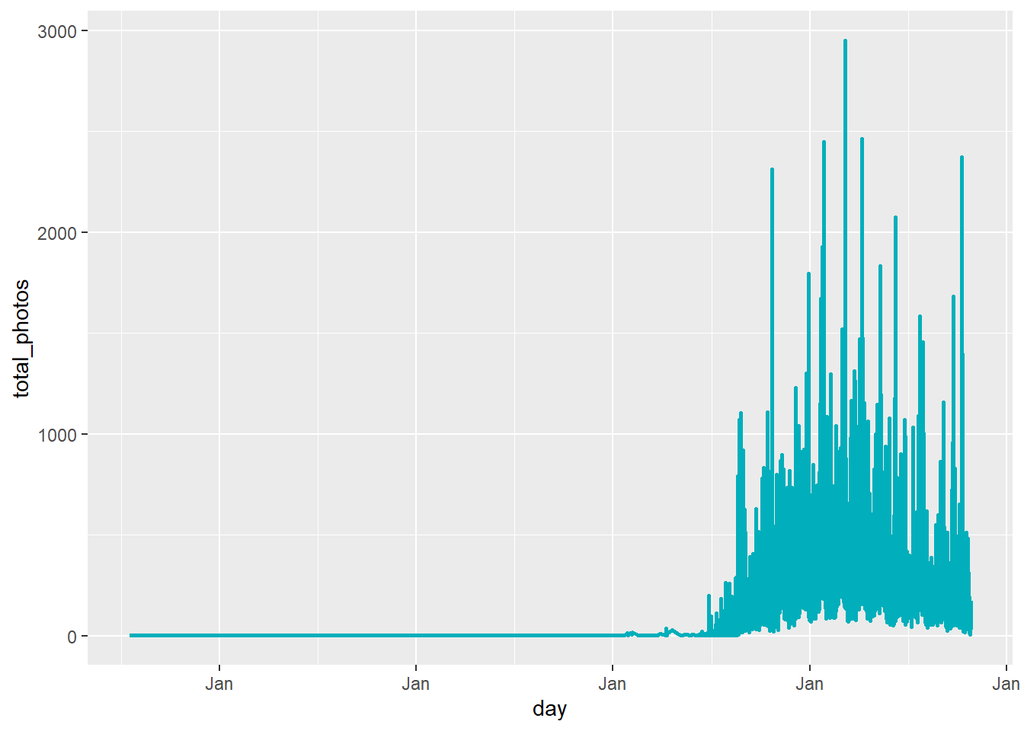

```r
p <- ggplot(daily_photography, aes(x = day, y = total_photos)) +
  geom_line(color = "#00AFBB", size = 1) +
  scale_x_date(date_labels = "%b")
p
```

5. We can apply a minimum to make the plot more legible

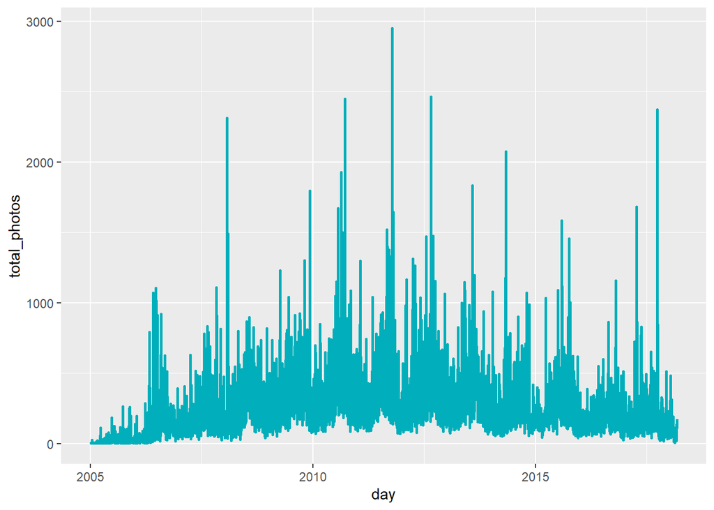

```r
## Let's set a minimum to omit the few points
## in before 2005
min <- as.Date("2005-1-1")
max <- NA

# Set axis limits c(min, max)
p + scale_x_date(limits = c(min, max))
```

6. Let’s smooth this data to see the trend of photographic sharing for the State.

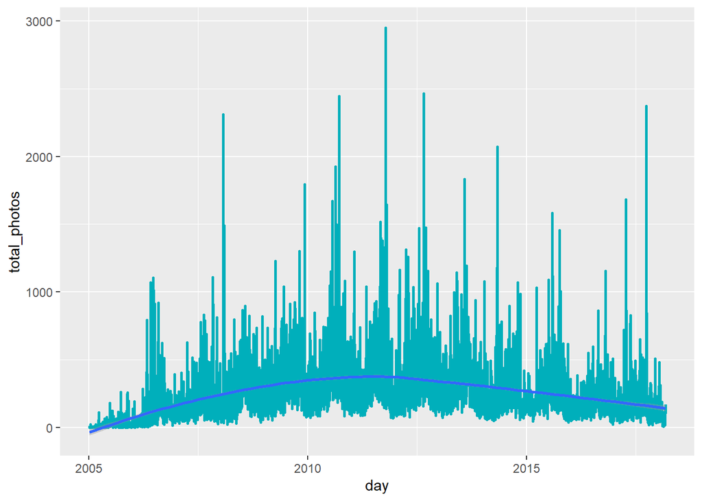

```r
p + stat_smooth(method = "loess", formula = y ~ x, size = 1) +
scale_x_date(limits = c(min, max))
```

We can also smooth it based on a spline function.

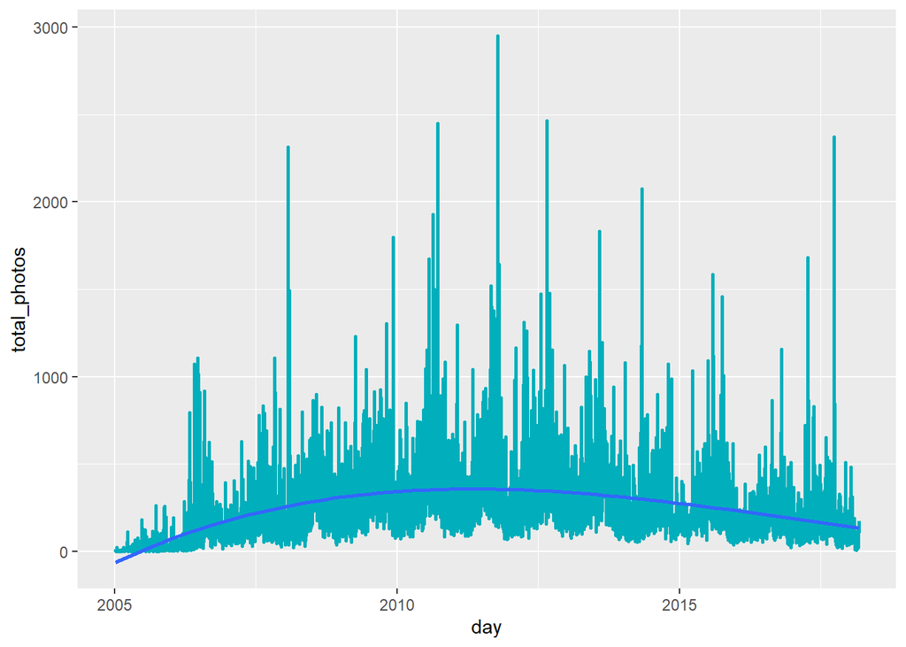

```r
p + geom_smooth(method = lm, formula = y ~ splines::bs(x, 3), se = FALSE) +
scale_x_date(limits = c(min, max))
```

7. We can also graph different categories of data at the same time. Here we can distinguish between nature and non-nature photographs.

```r
daily_nature <- MichFlickr %>%
  mutate(day = as.Date(date, format="%Y-%m-%d")) %>%
  group_by(day, Nature) %>% # group by the day column
  summarise(total_photos=sum(count))
```

[output not shown]

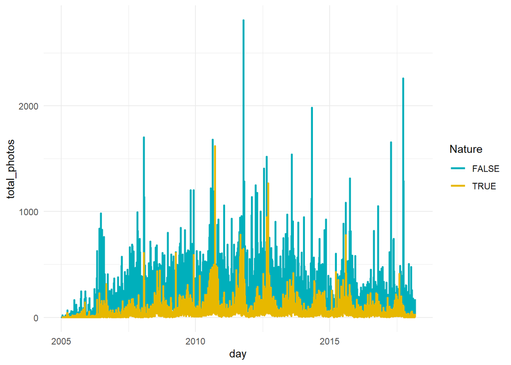

```r
ggplot(daily_nature, aes(x = day, y = total_photos)) +
  geom_line(aes(color = Nature), size = 1) +
  scale_color_manual(values = c("#00AFBB", "#E7B800")) +
  scale_x_date(limits = c(min, max)) +
  theme_minimal()
```

7.Let’s check if there is a monthly pattern of sharing photograph through Flickr. First we will use the `mutate()` function to parse the month and year from the date data. Here we are using the lubridate function to grab this data. [Here](https://rawgit.com/rstudio/cheatsheets/master/lubridate.pdf) is a cheatsheet for the lubridate package. We will summerize the total number of photographs based on the year and month using group_by (sometimes there are issues with this function due to different package dependancies dplyer and ggplot).

```r
daily_monthly <- daily_photography %>%
    mutate(month =  month(ymd(daily_photography$day), label = TRUE, abbr = FALSE),
           year  = year(as.Date(day, format = "%Y-%m-%d"))) %>%
    group_by(year,month) %>%
    summarise(total.qty = sum(total_photos))
daily_monthly
```

```
## # A tibble: 190 × 3
## # Groups:   year [21]
##     year month     total.qty
##    <dbl> <ord>         <dbl>
##  1  1975 June              1
##  2  1979 April             1
##  3  1979 August            1
##  4  2000 April             1
##  5  2000 June              2
##  6  2000 September        32
##  7  2000 November         14
##  8  2000 December         23
##  9  2001 April             7
## 10  2001 May               4
## # ℹ 180 more rows
```

8. Now that we have summarized this data in to another dataframe we can plot the different years of photography by month.

[figure not shown]

```r
daily_monthly  %>%
    filter(year > 2004)  %>%
    ggplot(aes(x = month, y = total.qty, group = year)) +
    geom_line(aes(color = as.factor(year))) +
    scale_color_discrete() +
    labs(title = "Total Flickr Photographs for Michigan", x = "", y = "Total Photographs",
         subtitle = "Activity is highest for the summer months") +
   theme_classic()
```

9. We can also do a similar weekly analysis. First we make dataframe that summerizes the data per week

```r
weekly <- daily_photography %>%
    mutate(weekday =  wday(ymd(daily_photography$day), label = TRUE, abbr = FALSE),
           year  = year(as.Date(day, format = "%Y-%m-%d"))) %>%
    group_by(year,weekday) %>%
    summarise(total.qty = sum(total_photos))
weekly
```

```
## # A tibble: 129 × 3
## # Groups:   year [21]
##     year weekday   total.qty
##    <dbl> <ord>         <dbl>
##  1  1975 Sunday            1
##  2  1979 Monday            1
##  3  1979 Saturday          1
##  4  2000 Sunday            1
##  5  2000 Monday           20
##  6  2000 Tuesday          19
##  7  2000 Wednesday         1
##  8  2000 Thursday         19
##  9  2000 Friday           12
## 10  2001 Monday            3
## # ℹ 119 more rows
```

Now we can plot this data.

[figure not shown]

```r
weekly  %>%
    filter(year > 2004)  %>%
    ggplot(aes(x = weekday, y = total.qty, group = year)) +
    geom_line(aes(color = as.factor(year))) +
    scale_color_discrete() +
    labs(title = "Total Flickr Photographs for Michigan", x = "", y = "Total Photographs",
         subtitle = "Activity is highest on the weekends") +
  theme_bw()
```

10. We can also look at peaks in time series data using the ggpmisc package, which was extension to ggplot. The extension emphasizes annotations and highlighting related to fitted models and data summaries. This is shown as text, tables and implemented using different equations. ggplot methods. For example, label the peaks of time series using stat_peaks. First let organize the data to include the date, month and year for filter to specific time periods. Let’s also grab only nature photographs.

```r
library(ggpmisc)
daily_nature_only <- MichFlickr %>%
 mutate(year = year(as.Date(date, format = "%Y-%m-%d")),
        month =  month(ymd(date), label = TRUE, abbr = FALSE)) %>%
  filter(Nature == TRUE) %>%
  group_by(date, year, month) %>% # group by the day column
  summarise(total_photos=sum(count))
daily_nature_only
```

```
## # A tibble: 4,650 × 4
## # Groups:   date, year [4,650]
##    date        year month     total_photos
##    <date>     <dbl> <ord>            <dbl>
##  1 2000-04-23  2000 April                1
##  2 2001-04-18  2001 April                1
##  3 2002-04-10  2002 April                1
##  4 2002-05-16  2002 May                  1
##  5 2002-09-17  2002 September            3
##  6 2003-09-20  2003 September            1
##  7 2004-03-23  2004 March                1
##  8 2004-03-24  2004 March                1
##  9 2004-06-30  2004 June                 8
## 10 2004-07-22  2004 July                 9
## # ℹ 4,640 more rows
```

11. Now we will plot the peaks and valleys by adding the stat_peaks and stat_valleys argument to the typical ggplot format. The arguments indicate what color to give and the time series peaks and valleys. We also have to use the POSIXct.

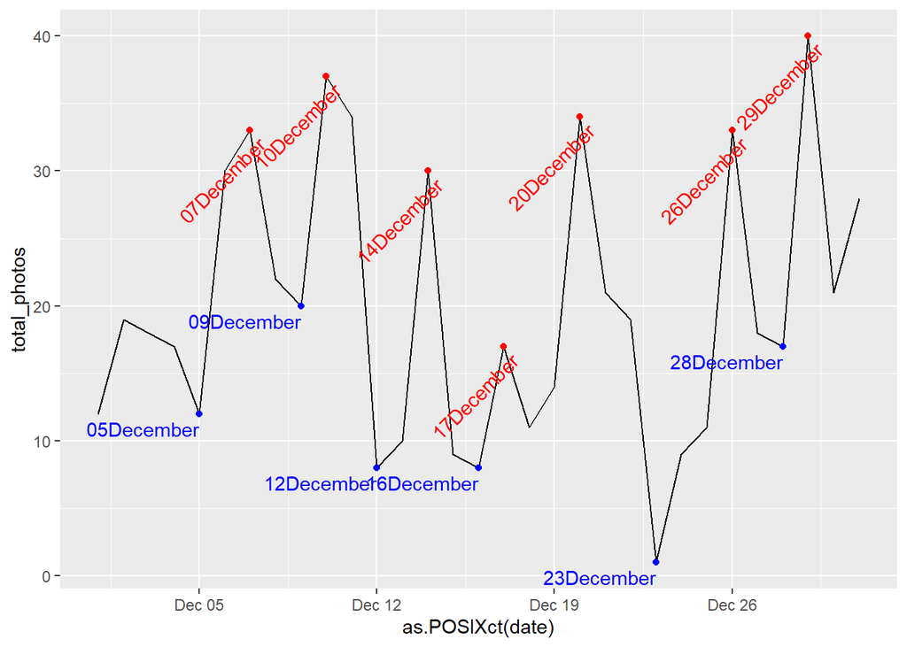

```r
daily_nature_only  %>%
    filter(year == '2011' & month=='December')  %>%
ggplot(aes(x = as.POSIXct(date), y = total_photos), as.numeric = FALSE) +
  geom_line() +
  stat_peaks(colour = "red") +
  stat_peaks(geom = "text", colour = "red", angle = 45,
               vjust = 1.5, hjust = 1,  x.label.fmt = "%d%B") +
  stat_valleys(colour = "blue") +
 stat_valleys(geom = "text", colour = "blue", angle = 360,
             vjust = 1.5, hjust = 1,  x.label.fmt = "%d%B")
```

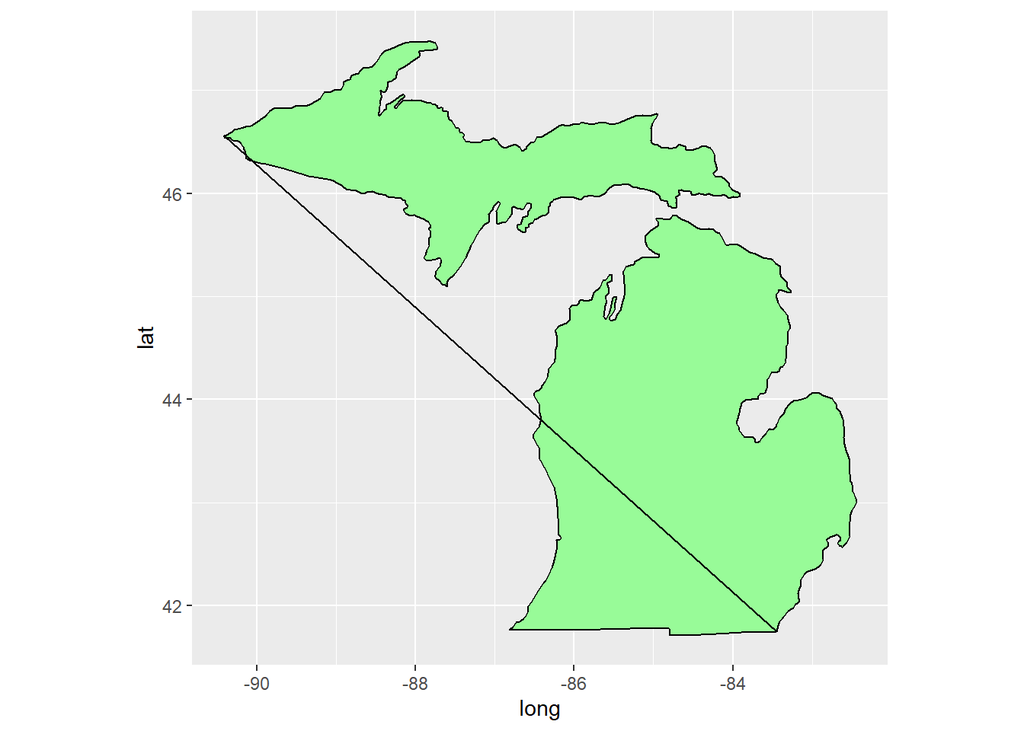

```r
######Data for Michigan
states <- map_data("state")
mich <- subset(states, region == "michigan")
mich <- states %>%
  filter(region == "michigan")
counties <- map_data("county")
mich_county <- subset(counties, region == "michigan")


ggplot(data = mich) +
  geom_polygon(aes(x = long, y = lat), fill = "palegreen", color = "black") +
  coord_fixed(1.3)
```

13. We can alter the data to another theme and also get rid of the weird line.

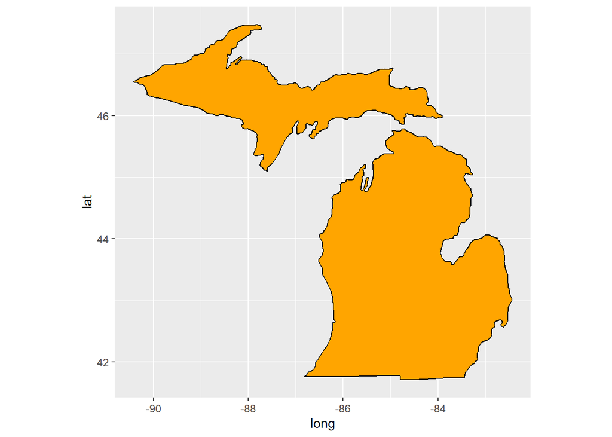

```r
mich <- ggplot(data = mich, mapping = aes(x = long, y = lat, group = group)) +
  coord_fixed(1.3) +
  geom_polygon(color = "black", fill = "orange")
mich
```